# Coursera Machine Learning HAR

Thomas Favre-Bulle

November 22, 2014

This study explores classification of execution quality for Unilateral Dumbbell Biceps Curls. The exercize can be well-executed (class A), or executed with various mistakes (classes B, C, D and E). To measure body movements, captors are places in the belt, glove, arm-band and the dumbell itself. In the original paper, Velloso et al use statistics of captor data like average, variance, maximum or range as best features for prediction. In the present study, however, this data is very sparse in the training set, and absent of the testing set. Therefore, the present study has to rely on instantaneous measurements only to assess the quality of an exercise.

Note: for reading convenience, libraries and data downloading code and charging is not displayed. Please see original Rmd file.

First, we clean the data to retain only columns corresponding to instantaneous measurements, excluding statistics columns surch as average, skewness or amplitude. These columns are easilly spotted because their name all start by an abbreviation of the said statistics. We also remove columns measuring index, time and subject. Finally, we check that all remaining variables have significant variance (not near zero), because a feature with zero variance is of no use for prediction.

```r
# Remove statistic values (average, variance, min, max...)
statstr <- c("max", "min", "skewness", "amplitude", "var", "total", "avg", "stddev", "kurtosis")

training2 <- training
for(str in statstr) {
  training2 <- training2[,grep(paste("^",str,sep="") , names(training2), value=TRUE, invert = TRUE)]
}

# Remove first columns, non measurements
training2 <- training2[,-c(1:7)]

# Check for near zero variance variables: there is none
trainNzv <- nearZeroVar(training2, saveMetrics=TRUE)
sum(trainNzv$nzv)
```

```
## [1] 0
```

The prediction is a classification problem: we need to classify the data in classes of either well performed exercize (A), or badly performed exercize (B,C,D and E). Because the output is not linear, we use a classification algorithm based on tree, and not a linear model algorithm.

To get an idea of the important predictors, we first produce a simple tree prediction model, and visualize the points of divergence between classes:

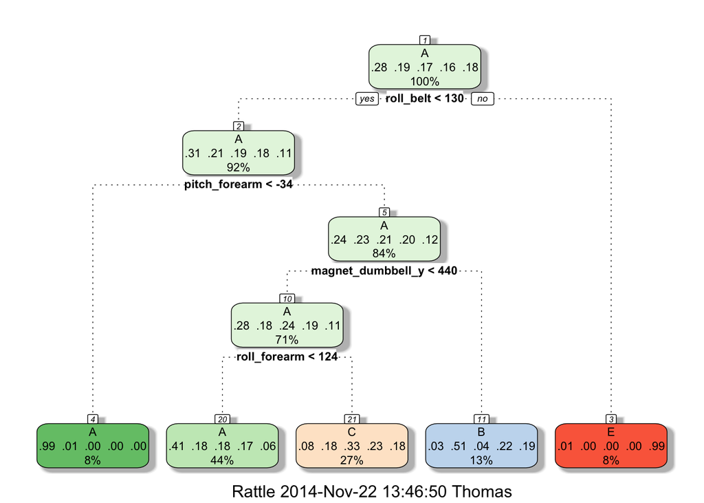

```r
# With caret, produce the tree model
modFitRpart <- train(classe ~., method="rpart",data=training2)

# Visualize the tree to highlight the variables of importance
fancyRpartPlot(modFitRpart$finalModel)
```

```r
# Summary of the model
modFitRpart
```

```
## CART
##
## 19622 samples
##    48 predictor
##     5 classes: 'A', 'B', 'C', 'D', 'E'
##
## No pre-processing
## Resampling: Bootstrapped (25 reps)
##
## Summary of sample sizes: 19622, 19622, 19622, 19622, 19622, 19622, ...
##
## Resampling results across tuning parameters:
##
##   cp    Accuracy  Kappa  Accuracy SD  Kappa SD
##   0.04  0.5       0.37   0.02         0.04
##   0.06  0.4       0.23   0.07         0.11
##   0.12  0.3       0.07   0.04         0.06
##
## Accuracy was used to select the optimal model using  the largest value.
## The final value used for the model was cp = 0.03568.
```

To improve prediction performance, we create a new prediction model based on random forest:

```r
# Random forest model
modFitRf <- randomForest(classe ~., data = training2)
```

We examine the importance of variable in the forest, regarding mean decrease in node impurity. Roll of belt censor is still the most important variable. Overall, variables identified as important in the single tree model are still high in the ranking of importance.

```r
varImpRf <- as.data.frame(importance(modFitRf, type = 2))
varImpRf$variable <- rownames(varImpRf)
row.names(varImpRf) <- NULL
head(varImpRf[order(-varImpRf[,1]),])
```

```
##    MeanDecreaseGini          variable
## 1            1283.7         roll_belt
## 3             933.7          yaw_belt
## 36            790.3 magnet_dumbbell_z
## 38            763.6     pitch_forearm
## 2             712.0        pitch_belt
## 35            691.2 magnet_dumbbell_y
```

The distribution of variables of importance demonstrate a power distribution, with many variables of little importance and a limited number of variables of great importance.

```
## stat_bin: binwidth defaulted to range/30. Use 'binwidth = x' to adjust this.
```

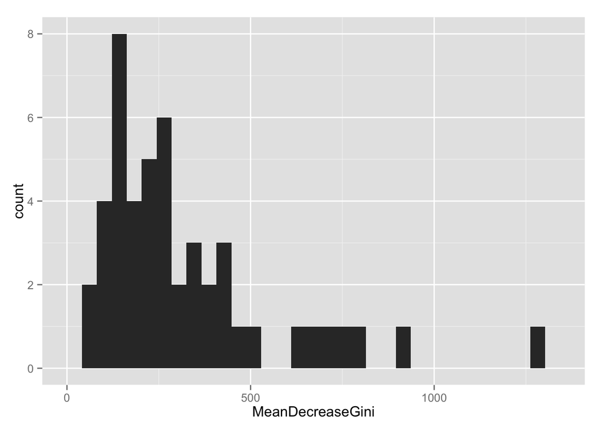

```r
qplot(MeanDecreaseGini, data=varImpRf, geom="histogram")
```

Random forest includes a form of cross-validation in the out-of-bag (OOB) estimate of error rate, because each tree uses a different bootstrap sample from the training data. The OOB estimate of error rate for this model is low (≈ 0.3%). It is therefore expected that very few cases will be misclassified on a new testing set.

As a conclusion, the random forest algorithm indeed classified correctly 100% of the testing cases in the prediction assignment.

```r
modFitRf
```

```
##
## Call:
##  randomForest(formula = classe ~ ., data = training2)
##                Type of random forest: classification
##                      Number of trees: 500
## No. of variables tried at each split: 6
##
##         OOB estimate of  error rate: 0.31%
## Confusion matrix:
##      A    B    C    D    E class.error
## A 5579    1    0    0    0   0.0001792
## B   11 3783    3    0    0   0.0036871
## C    0   12 3409    1    0   0.0037989
## D    0    0   24 3190    2   0.0080846
## E    0    0    2    4 3601   0.0016634
```